# Lecture 5 Notes

Quantitative Data Analysis

# Introduction

- Last time we began our work on data visualisation
- This time, we will continue this discussion
- We will learn how to work with additional data types and geometries
- We will reflect once more on the role of data visualisation within data analysis

# Box plots

- Density plots can be a good way to show the distribution of a continuous variable across different groups
- It can get messy when there are too many categories
- An alternative is the box plot
- It is a way of visualising the quartiles by group
- It also makes comparing medians easier
- We have to add a *geom_boxplot* to the plot, include SEX as the x variable in our aesthetic mapping and apply the log scale to the y axis instead of the x axis
- We can start by looking at the SEX variable, although our density plot was probably a better way of looking at it

# Box plot of wages by sex

```r
lfs %>%
  ggplot(aes(SEX, HOURPAY)) +
  geom_boxplot() +
  theme_minimal() +
  scale_y_log10() +
  labs(title = "Distribution of hourly wage by sex",
     subtitle = "Logarithmic scale",
     x = "Sex",
     y = "Hourly wage (£)",
     caption = "Source: Quarterly Labour Force Survey - January-March 2025") +
  theme(legend.title = element_blank())
```

# Box plot of wages by sex

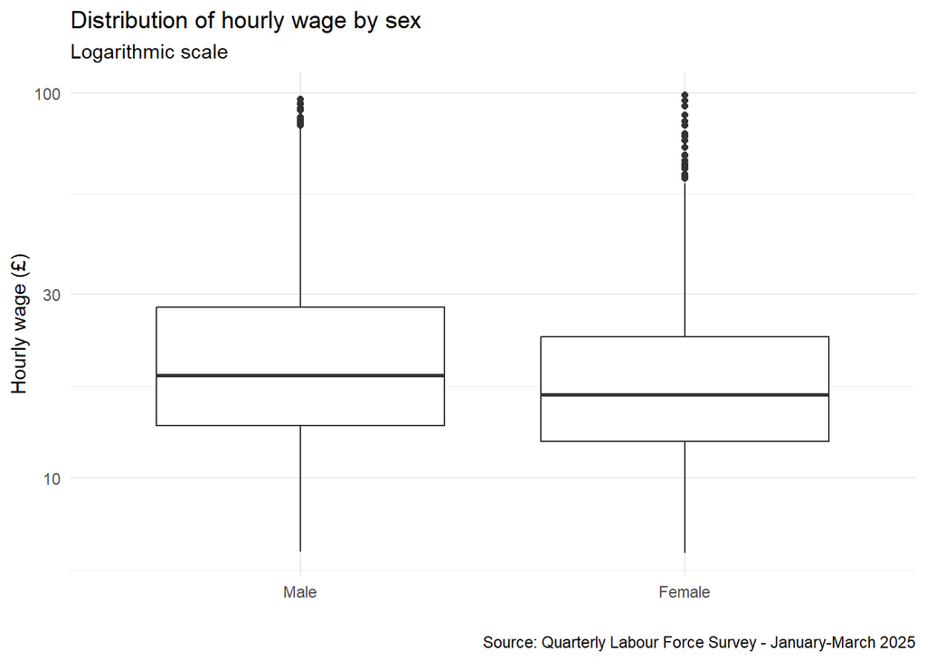

# Interpretation

- The bar in the middle of the box shows the median
- The bottom of the box is the 1st quartile
- The top is the 3rd quartile
- This means that 50% of the observations are in the box
- The whiskers mark the minimum and maximum excluding the outliers
- The outliers are shown with dots

# Wages by region

```r
lfs %>%
  ggplot(aes(GOR9D,HOURPAY)) +
  geom_boxplot() +
  labs( title = "Distribution of hourly wage by region",
        subtitle = "Logarithmic scale",
        x = "",
        y = "Hourly wage (£)",
        caption = "Source: Quarterly Labour Force Survey - January-March 2025") +
  theme_minimal() +
  scale_y_log10() +
  theme(legend.title = element_blank())
```

# Wages by region

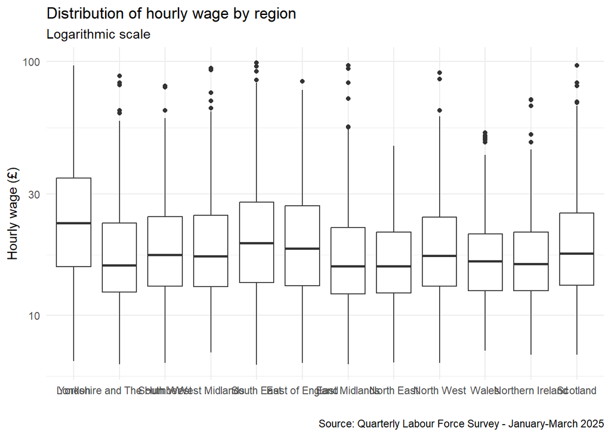

# Room for improvement

- The labels on the horizontal axis clash, making them hard to read
- It’s hard to compare some of the categories to see which are higher and lower
- We have a few options regarding the labels
- We could rotate the labels, or flip the coordinate system of the plot
- We could arrange the regions in descending order
- Factors can be reordered in this way using the *fct_reorder* function

# Improving the plot

```r
lfs %>%
  mutate(GOR9D = fct_reorder(GOR9D,HOURPAY,median,.desc=TRUE)) %>%
  ggplot(aes(GOR9D,HOURPAY)) +
  geom_boxplot() +
  labs( title = "Distribution of hourly wage by region",
        subtitle = "Logarithmic scale",
        x = "",
        y = "Hourly wage (£)",
        caption = "Source: Quarterly Labour Force Survey - January-March 2025") +
  theme_minimal() +
  scale_y_log10() +
  theme(legend.title = element_blank()) +
  coord_flip()
```

# Improving the plot

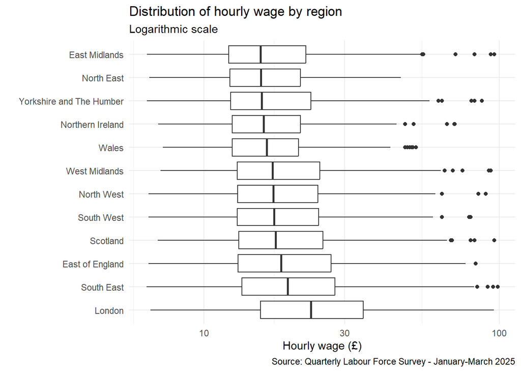

# The improved plot

- Most importantly, we can now read the labels
- We can also better see which regions have the highest wages and which have the lowest
- Let’s try another variable
- This time we will look at wages by industry

# Wages by industry

```r
lfs %>%
  mutate(INDE07M = fct_reorder(INDE07M,HOURPAY,median,.desc=TRUE)) %>%
  ggplot(aes(INDE07M,HOURPAY)) +
  geom_boxplot() +
  labs( title = "Distribution of hourly wage by industry",
        subtitle = "Logarithmic scale",
        x = "",
        y = "Hourly wage (£)",
        caption = "Source: Quarterly Labour Force Survey - January-March 2025") +
  theme_minimal() +
  scale_y_log10() +
  theme(legend.title = element_blank()) +
  coord_flip()
```

# Wages by industry

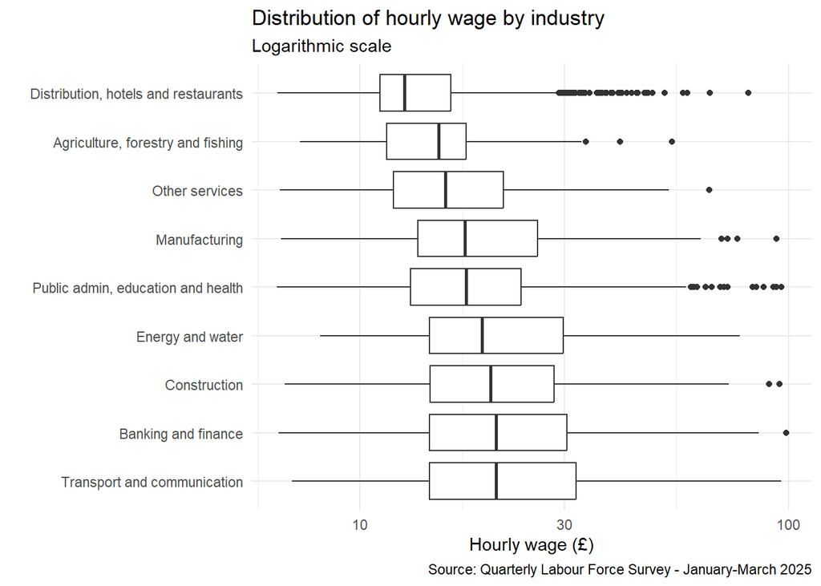

# Adding a third variable

- So far we have two variables her
  - Industry is mapped to the x axis
  - Wage is mapped to the y axis
- We can add a third variable by mapping it to an avaialble aesthetic
- Let’s map the SEX variable to the fill of the boxes

# Wages by industry and sex

```r
lfs %>%
  mutate(INDE07M = fct_reorder(INDE07M,HOURPAY,median,.desc=TRUE)) %>%
  ggplot(aes(INDE07M,HOURPAY)) +
  geom_boxplot(aes(fill=SEX)) +
  labs( title = "Distribution of hourly wage by industry",
        subtitle = "Logarithmic scale",
        x = "",
        y = "Hourly wage (£)",
        caption = "Source: Quarterly Labour Force Survey - January-March 2025") +
  theme_minimal() +
  scale_y_log10() +
  theme(legend.title = element_blank()) +
  coord_flip()
```

# Wages by industry and sex

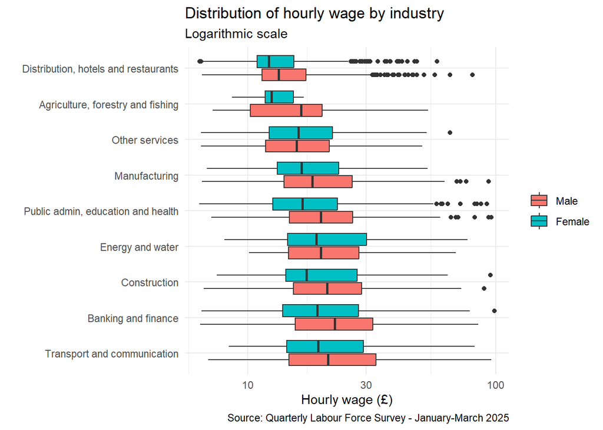

# Interpretation

- We can see here that there is quite a bit of variation in wages between industry
- We can also see the disparity in pay between men and women
- It looks like in almost every industry, men are paid more than women
- In some industries, the disparity is minimal
- In some, e.g., finance, there is a substantial difference

# An alternative way of visualising these

- We have been using the boxplot geometry
- There area couple of other options which would give more detail
- What we want to do is strike a balance between clearly presenting a patterns and presenting detail and nuance
- Too much detail may obscure patterns and make the plot hard to read
- One direct alternative to the boxplot is the *violin plot*
- It is a relative of the density curve we met earlier
- Let’s use education and wages as an example

# Wages and education

```r
lfs %>%
  ggplot(aes(HIQUL22D,HOURPAY)) +
  geom_violin() +
  labs( title = "Distribution of hourly wage by education",
        subtitle = "Logarithmic scale",
        x = "",
        y = "Hourly wage (£)",
        caption = "Source: Quarterly Labour Force Survey - January-March 2025") +
  theme_minimal() +
  scale_y_log10() +
  theme(legend.title = element_blank()) +
  coord_flip()
```

# Wages and education

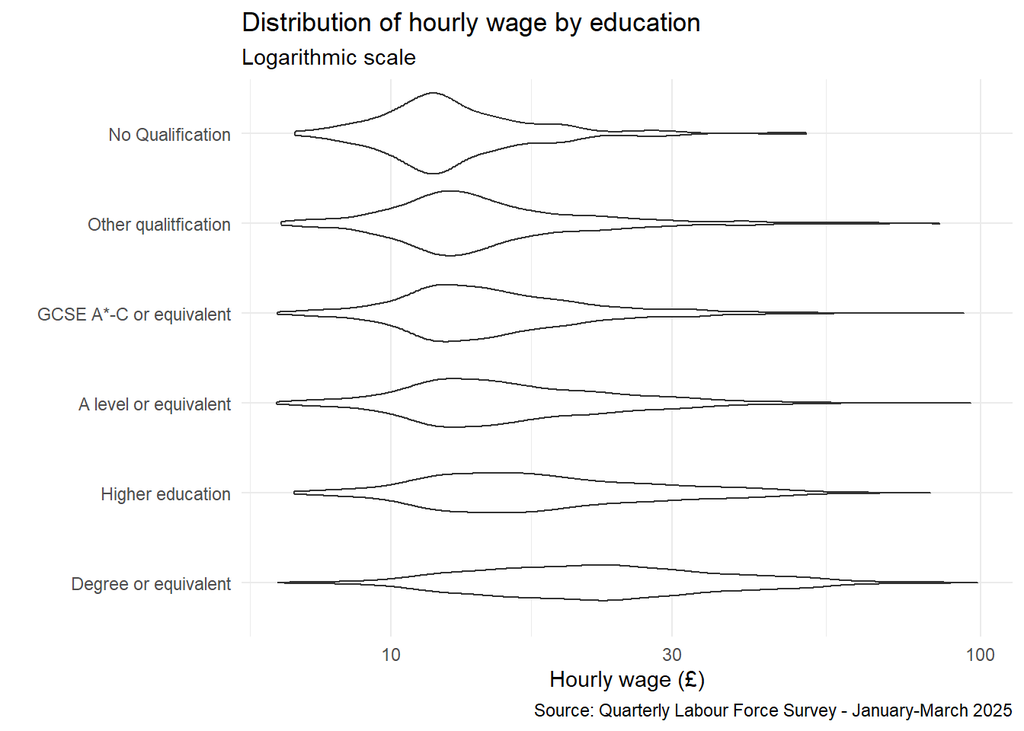

# Interpretation

- The shapes are thicker where there is a higher density of observations
- This gives some additional information over what the boxplot showed
- It makes some other features harder to see e.g., the median
- We can go crazy and combine a box and violin plot!
- This would give us the best of both worlds
- We’ll have to make the boxes a little thinner using the *width* argument

# Wages and education

```r
lfs %>%
  ggplot(aes(HIQUL22D,HOURPAY)) +
  geom_violin() +
  geom_boxplot(width=0.2) +
  labs( title = "Distribution of hourly wage by education",
        subtitle = "Logarithmic scale",
        x = "",
        y = "Hourly wage (£)",
        caption = "Source: Quarterly Labour Force Survey - January-March 2025") +
  theme_minimal() +
  scale_y_log10() +
  theme(legend.title = element_blank()) +
  coord_flip()
```

# Wages and education

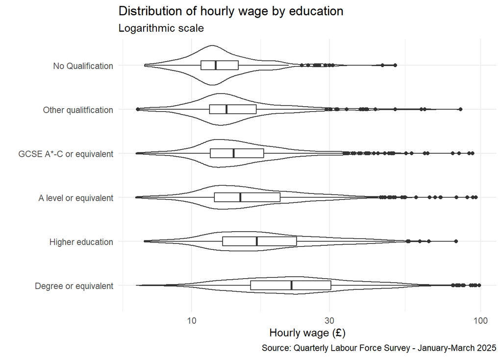

# One last alternative

- We have now seen boxplot and violin geometries in action
- There is also an option where we use points
- We won’t use *geom_point* though because too many of the points would overlap because there are only a finite number of x values
- We will use *geom_jitter* which offsets the points on the x axis
- Let’s look at an example with the job seniority measure

# Jitter plot of wages and seniority

```r
lfs %>%
  ggplot(aes(NSECMJ20,HOURPAY)) +
  geom_jitter() +
  labs( title = "Distribution of hourly wage by seniority",
        subtitle = "Logarithmic scale",
        x = "",
        y = "Hourly wage (£)",
        caption = "Source: Quarterly Labour Force Survey - January-March 2025") +
  theme_minimal() +
  scale_y_log10() +
  theme(legend.title = element_blank()) +
  coord_flip()
```

# Jitter plot of wages and seniority

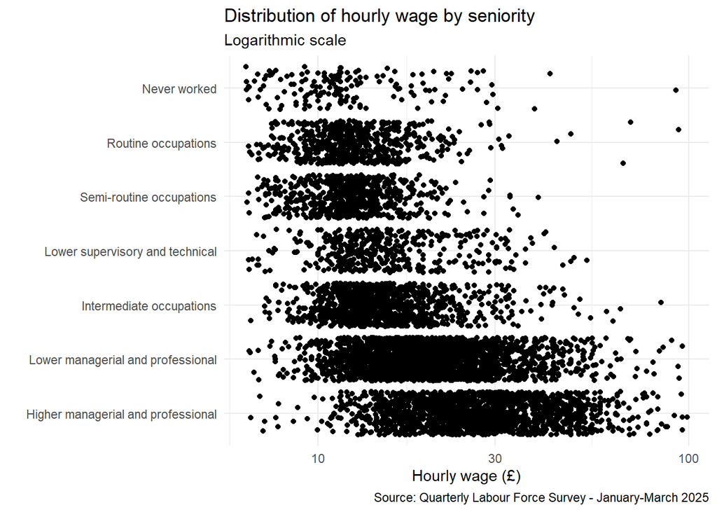

# Interpretation

- We can see that more senior jobs seem to be associated with higher wages
- We have a degree of overplotting i.e., many of the points in the middle of the distributions overlap
- We can improve this by reducing the opacity of the points using the *alpha* argument

# Jitter plot of wages and seniority

```r
lfs %>%
  filter(NSECMJ20!="Small employers and own account workers") %>%
  ggplot(aes(NSECMJ20,HOURPAY)) +
  geom_jitter(alpha=0.05) +
  labs( title = "Distribution of hourly wage by seniority",
        subtitle = "Logarithmic scale",
        x = "",
        y = "Hourly wage (£)",
        caption = "Source: Quarterly Labour Force Survey - January-March 2025") +
  theme_minimal() +
  scale_y_log10() +
  theme(legend.title = element_blank()) +
  coord_flip()
```

# Jitter plot of wages and seniority

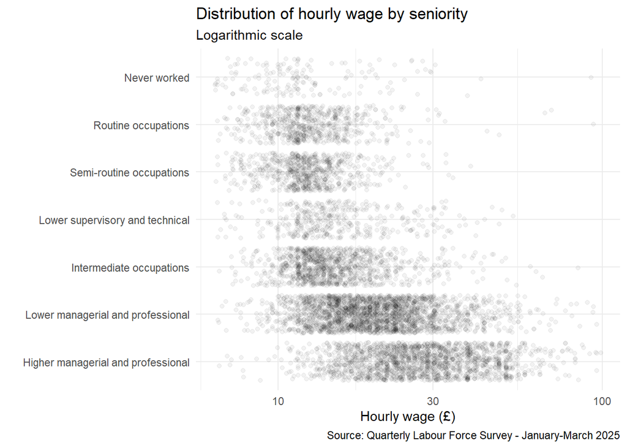

# Jitter plot of wages and seniority

[figure not shown]

# Plotting two ratio variables

- Our examples so far have been looking at how a ratio variable varies across categories
- We may also want to look at the relationship between two ratio variables
- Let’s consider wage and age
- We’ll stick with the logarithmic scale for wages
- we will begin by using the point geometry

# Hourly wage versus age

```r
lfs %>%
  ggplot(aes(AGE,HOURPAY)) +
  geom_point() +
  theme_minimal() +
  scale_y_log10()
```

# Hourly wage versus age

[figure not shown]

# Problems

- We can see a relationship in the plot
- It looks a bit odd because age is presented in years i.e., it is measured on a discrete scale
- This is causing clear columns to appear
- There are also a lot of points which overlap
- We can deal with the columns by jittering the points
- This adds some random noise to deal with some of the overlap
- This somewhat distorts the data so make it clear to the reader when you do this

# Problems

- We can jitter the points by setting the *geom_point* position argument to jitter
- We can also replace the *geom_point* with *geom_jitter*
- It will also make the plot more readable if we adjust the transparency of the points with the alpha argument
- We could also consider adjusting the size of the points with the *size* argument

# Hourly wage versus age

```r
lfs %>%
  ggplot(aes(AGE,HOURPAY)) +
  geom_jitter(alpha=0.2) +
  theme_minimal() +
  scale_y_log10() +
  labs(title = "Wage versus age",
       x = "Age",
       y = "Hourly wage (£)")
```

# Hourly wage versus age

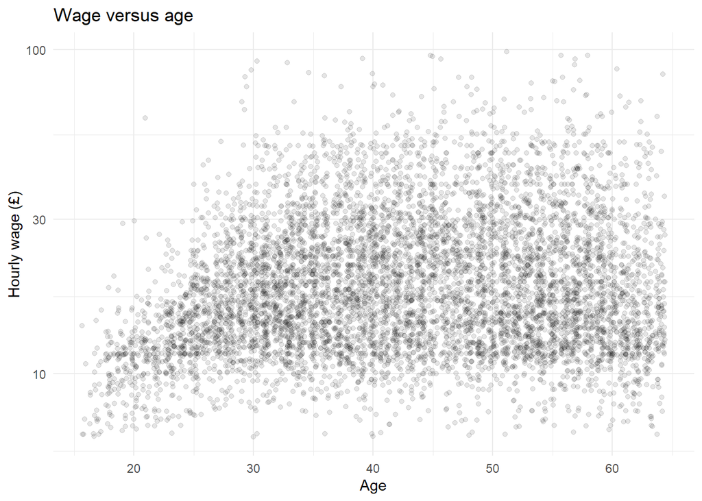

# Regional dispaities in the wage gap

- Let’s compare the wage gap across different regions
- Once again, we have to combine three variables
- There are many ways we can do this, some will give a clearer picture than others
- We will use the *facet* option of ggplot
- This allows us to break the plot down by subgroups
- We can use up to two factors to do this

# Wage distribution by sex and region

```r
lfs %>%
  ggplot(aes(HOURPAY, fill=SEX)) +
  geom_density(alpha=0.3) +
  theme_minimal() +
  scale_x_log10() +
  facet_wrap(~GOR9D) +
  theme(legend.position = "top",
        legend.title = element_blank())  +
  labs(title = "Wage distribution by sex and region",
       x = "Hourly wage (£)",
       y = "Density")
```

# Wage distribution by sex and region

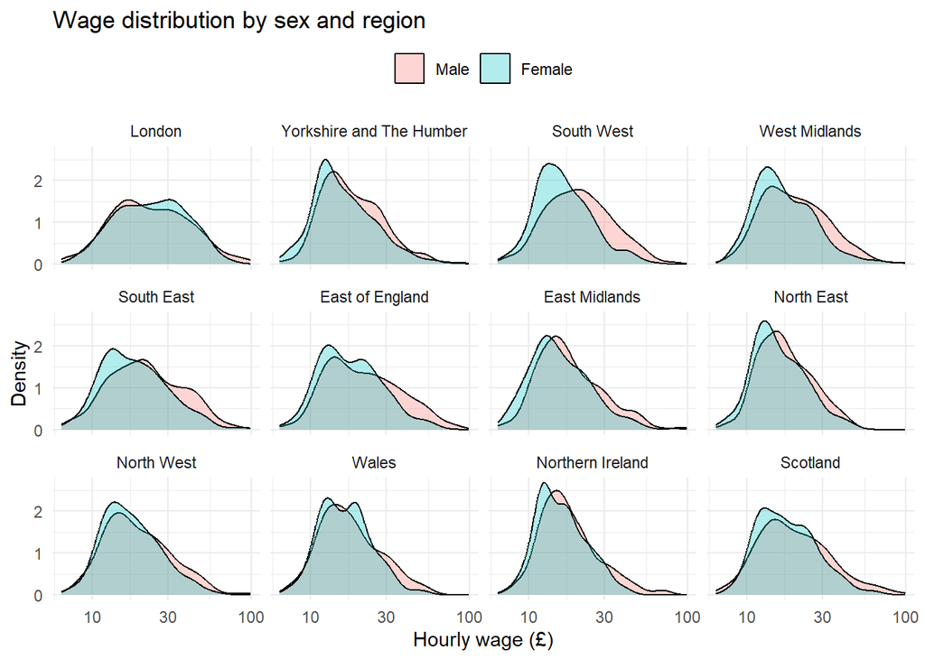

# Displaying four variables

- We can use faceting to display four variables
- Suppose we want to look at the wage gap by job status
- We can consider whether a position is full-time or part-time
- We can also look at whether a job is permanent or not permanent

# Wages by sex and job type

```r
lfs %>%
  ggplot(aes(HOURPAY, fill=SEX)) +
  geom_density(alpha=0.4) +
  theme_minimal() +
  scale_x_log10() +
  facet_grid(FTPT~JOBTYP) +
  theme(legend.position = "top",
        legend.title = element_blank()) +
  labs(title = "Wages by sex and type of job",
       x = "Hourly wage (£)",
       y= "Density")
```

# Wages by sex and job type

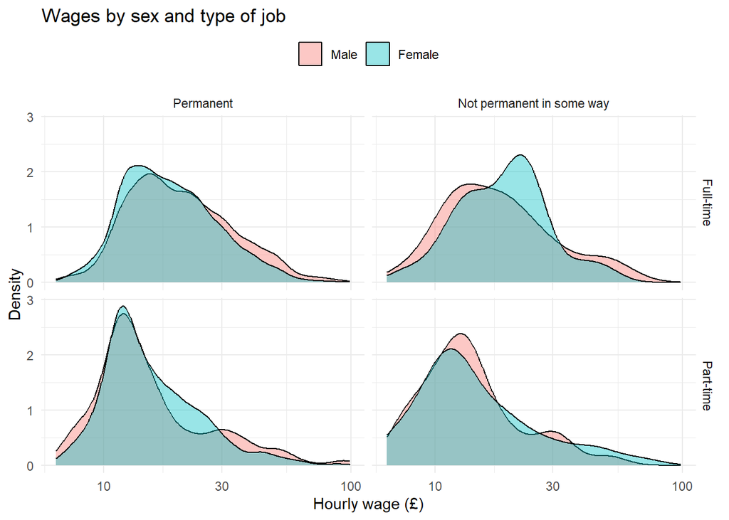

# Average income by education and income

- Another useful geometry to work with is the *tile* geometry
- This allows us to visualise a summary statistic by group
- Suppose we want to look at the average wage for each education level in different industries
- First we have to process the data to generate the mean income per group
- We can do this using *group_by* and then display the result using the tile geometry

# Average income by education and income

```r
lfs %>%
  group_by(HIQUL22D,INDE07M) %>%
  summarise(mean_wage = mean(HOURPAY)) %>%
  ggplot(aes(HIQUL22D,INDE07M,fill=mean_wage)) +
  geom_tile() +
  theme(axis.text.x = element_text(angle = 90)) +
  labs(title = "Wage by industry and education",
       fill = "Mean hourly wage (£)",
       x = "Highest qualification attained",
       y = "Industry")
```

# Average income by education and income

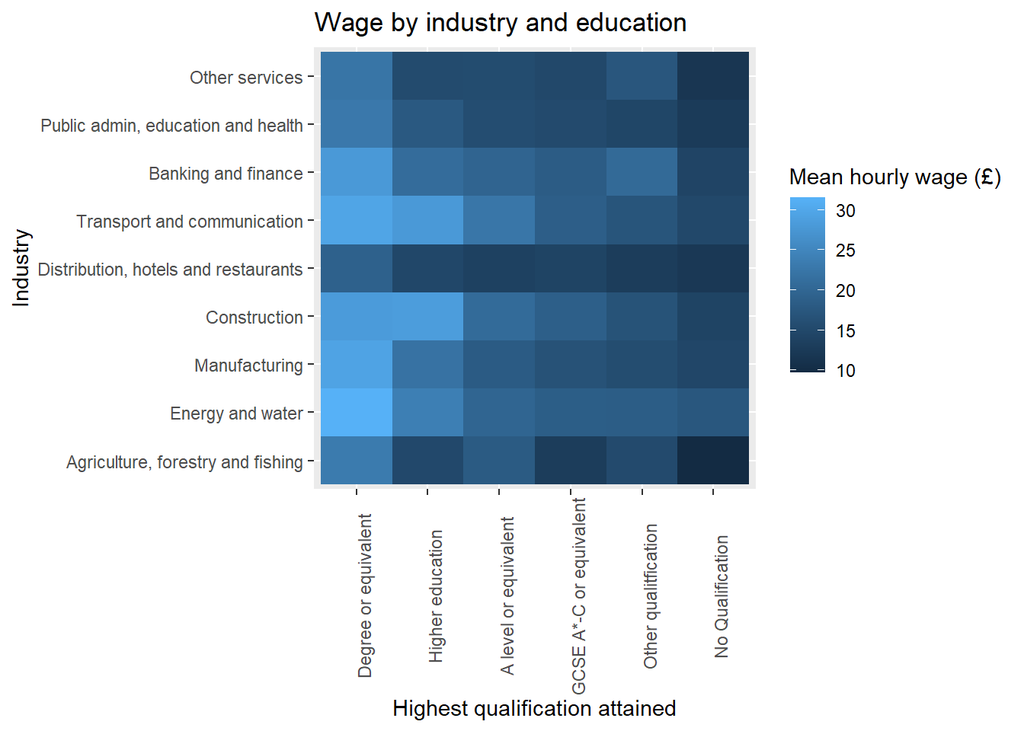

# Tile plot

- This plot lets us quickly see that more education tends to result in higher wages
- It also allows us to see that average wages are higher in some industries compared to others
- There also appear to be some differences in the returns to education across industries
- We could further split this by sex

# Average income by education, income, and sex

```r
lfs %>%
  group_by(HIQUL22D,INDE07M,SEX) %>%
  summarise(mean_wage = mean(HOURPAY)) %>%
  ggplot(aes(HIQUL22D,INDE07M,fill=mean_wage)) +
  geom_tile() +
  theme_minimal() +
  theme(axis.text.x = element_text(angle = 90)) +
  labs(title = "Wage by industry and education",
       fill = "Mean hourly wage (£)",
       x = "Highest qualification attained",
       y = "Industry") +
  facet_wrap(~SEX)
```

# Average income by education, income, and sex

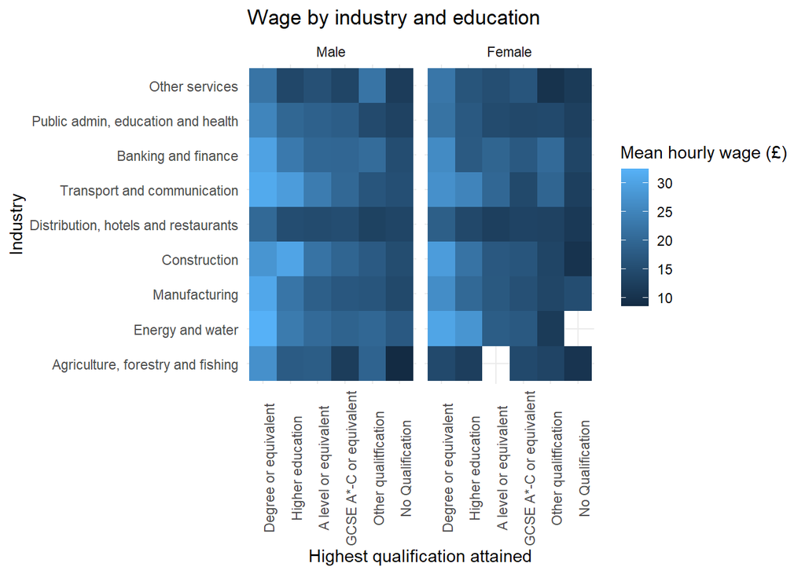

# Education, industry, and sex

# Distribution of categorical variables

- Histograms and density plots let us look at the distribution of a continuous variable
- We might be interested in the distribution of a categorical variable such as education or industry
- We can use a bar chart to do this
- The output looks somewhat similar to the histogram but it is a different type of plot

# Employment by industry

```r
lfs %>%
  mutate(INDE07M = fct_infreq(INDE07M) %>% fct_rev) %>%
  ggplot(aes(INDE07M)) +
  geom_bar() +
  theme_minimal() +
  labs(title = "Employment by industry",
       x = "",
       y = "Count") +
  coord_flip()
```

# Employment by industry

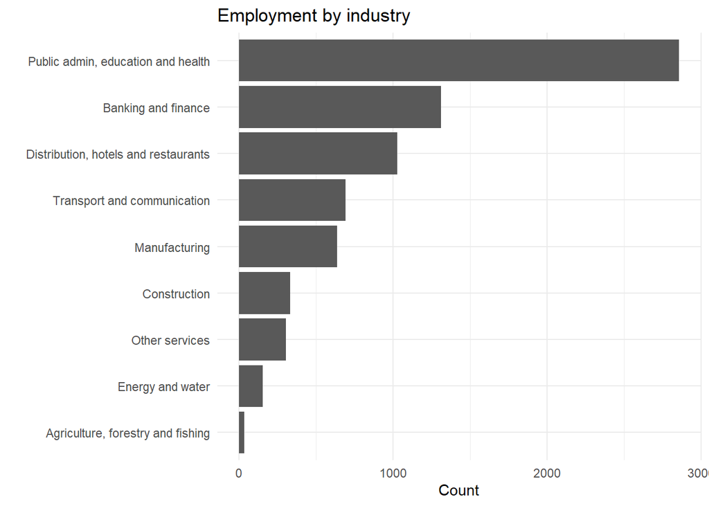

# Employment by industry

- This lets us clearly see which industries employ most people
- We have used a few tricks: *fct_infreq*, *fct_rev*. *coord_flip*
- We should probably be careful in interpreting any breakdowns in the AFF industry as there are few people employed in that industry
- Suppose we want to look at education in all this

# Employment by industry and education

```r
lfs %>%
  mutate(INDE07M = fct_infreq(INDE07M) %>% fct_rev) %>%
  ggplot(aes(INDE07M, fill=HIQUL22D)) +
  geom_bar() +
  theme_minimal() +
  labs(fill = "Education",
       title = "Employment by industry and education",
       x = "",
       y = "Count") +
  coord_flip()
```

# Employment by industry and education

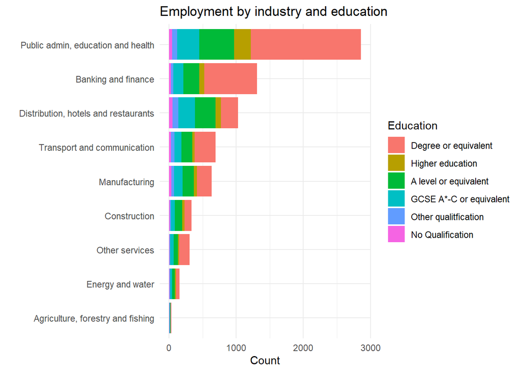

# Changes

- This is hard to read because some of the groups contain few people
- The colours are also difficult to see
- I’m going to use some colours from the *ggthemes* package, so we will have to load that
- Instead of looking at the count of people, lets look at what share of employment in each industry has each type of education

# Education share by industry

```r
library(ggthemes)

lfs %>%
  mutate(INDE07M = fct_infreq(INDE07M) %>% fct_rev) %>%
  ggplot(aes(INDE07M, fill=HIQUL22D)) +
  geom_bar(position="fill") +
  theme_minimal() +
  labs(fill = "Education",
       title = "Employment by industry and education",
       x = "",
       y = "Share") +
  coord_flip() +
  scale_fill_colorblind()
```

# Education share by industry

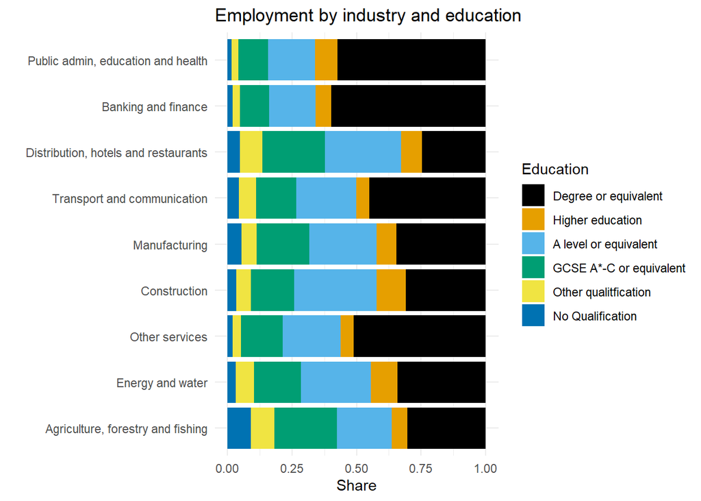

# Education share by industry and sex

```r
lfs %>%
  mutate(INDE07M = fct_infreq(INDE07M) %>% fct_rev) %>%
  ggplot(aes(INDE07M, fill=HIQUL22D)) +
  geom_bar(position="fill") +
  theme_minimal() +
  labs(fill = "Education",
       title = "Employment by industry and education",
       x = "",
       y = "Share") +
  coord_flip() +
  scale_fill_colorblind() +
  facet_wrap(~SEX)
```

# Education share by industry and sex

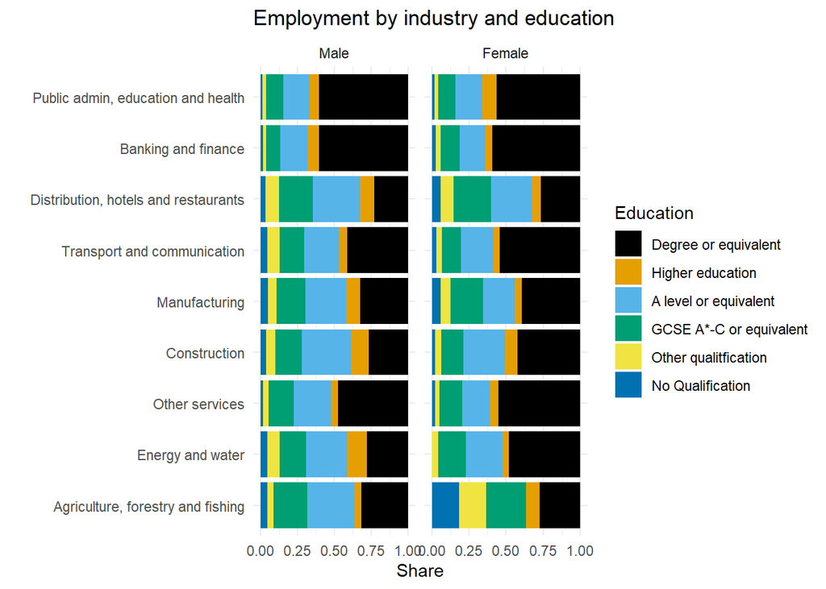

# Interpretation

- We now can’t see the size of the industry, although the order in which they appear indicates their size
- We can see what share of workers in each industry have different levels of education
- This can be broken down by sex to look for differences

class: inverse, center, middle # Some advice on data visualisation

# What have we covered

- We have now had an overview of a variety of types of plots
- Our plots have been made by combining different elements in different ways
- We could therefore make a vast array of different plot types
- It all boils down to the basic concept of the grammar of graphics
- Think about how these elements can be best combined for your data and topic

# Including plots in a publication

- Some plots you will only look at on your screen
- Some will be so good that you will want to include them in your final write-up
- If they are being included in an output, then take time to make them look good
- Everything should be properly labelled e.g., avoid raw variables names. Nobody wants to see a plot of G3652xjw because none of use know what that is
- Also make sure labels don’t clash
- You should explain in the text what a plot shows and what you want the reader to take from it
- Having said that, a plot should be as self-explanatory as possible

# Do you need a plot?

- Don’t cram too much into one plot
- Perhaps there is a better way of displaying data
- Don’t neglect tables. Tables are a great way of displaying information and are sometimes more informative than a plot
- Some data can be presented in the text without having to be in a table e.g., the sample includes 25 men and 24 women

# Classifying plots

- I like to think of two dimensions for classifying a plot
- Plots vary in how useful they are in displaying information
- They also vary in how beautiful they are
- Aim to make useful and beautiful plots where possible
- Avoid useless plots, and definitely avoid useless and ugly plots

# Other types of visualisation

- We have considered only static visualisations
- It is also possible to make dynamic, interactive visualisations
- R has a variety of tools for this
- Some plots are also in three spatial dimensions
- However, many need to end up on paper (or on a screen as a picture)
- Some believe that 3D plots are to be avoided at all costs

# Visualising spatial data

- Some data have a spatial reference (including ours to some extent)
- It is often helpful to display these on maps
- R allows us to do this in a variety of different ways (we can even use *ggplot2*)
- This goes beyond the scope of this course, but it’s something to think about
- It may also come in useful to you in future

# Summary

- A picture is worth one thousand words
- A good data visualisation is a powerful and persuasive way of making a point
- Research has been done showing that a good chart can go a long way to affecting policy change when shown to policy makers
- It is also a great way to make your work accessible to a wider audience
- Make sure any visualisation you produce is properly labelled and explained